# 52414: Lab 2

## Answer 4

a) The purpose of the plots is to find the clubs with the most varied nationalities. The first plot shows the 8 clubs with the greatest number of distinct nationalities in the club. The problem with the plot is that it takes no account of the fact that there are different numbers of players in each club. It is thus necessary to examine the ratio of nationalities in each club. Therefore, the second plot shows the ratio of nationalities for each of the top 12 clubs, using the function DIV (that calculate the “index-of-coincidence”). This plot shows the 12 clubs with the lowest ratio of nationalities per club.

b) The plots have the following problems: 1) The names of the clubs on the x axis are superimposed over each other. 2) The plots have no titles. 3) The variable DIV on the y axis is not sufficiently clear as to what is represents. 4) The plot contains a column representing NA, which should have been removed from the plot. 5) All the columns are colored in grey, making it difficult to distinguish the clubs represented in each column.

c) I fixed the problematic issues:

```r
DIV <- function(category_vec){
  t <- table(category_vec)
  p <- t/sum(t)
  return(sum(p^2))
}

cleaned_data <- fifa_players %>% select(Nationality,Club) %>% na.omit()

number_of_nationality_in_club <- cleaned_data %>% group_by(Club, Nationality) %>% summarise(count = n()) %>% group_by(Club) %>% summarise(N_nation=n()) %>% arrange(desc(N_nation)) %>% mutate(Club = factor(Club, level=unique(Club)))
DIV_in_club <- cleaned_data %>% group_by(Club) %>% summarise(DIV = DIV(Nationality))%>% arrange(DIV)%>% mutate(Club = factor(Club,level=unique(Club)))
```

a fixed code - part 1:

```r
number_of_nationality_in_club <- cleaned_data %>% group_by(Club,Nationality) %>% summarise(count = n()) %>% group_by(Club) %>% summarise(N_nation=n())  %>% arrange(desc(N_nation)) %>% mutate(Club = factor(Club,level=unique(Club))) %>% filter(Club!="")
DIV_in_club <- cleaned_data %>% group_by(Club) %>% summarise(DIV = DIV(Nationality)) %>% arrange(DIV)%>% mutate(Club = factor(Club,level=unique(Club))) %>%  filter(Club!="")
```

a fixed code - part 2:

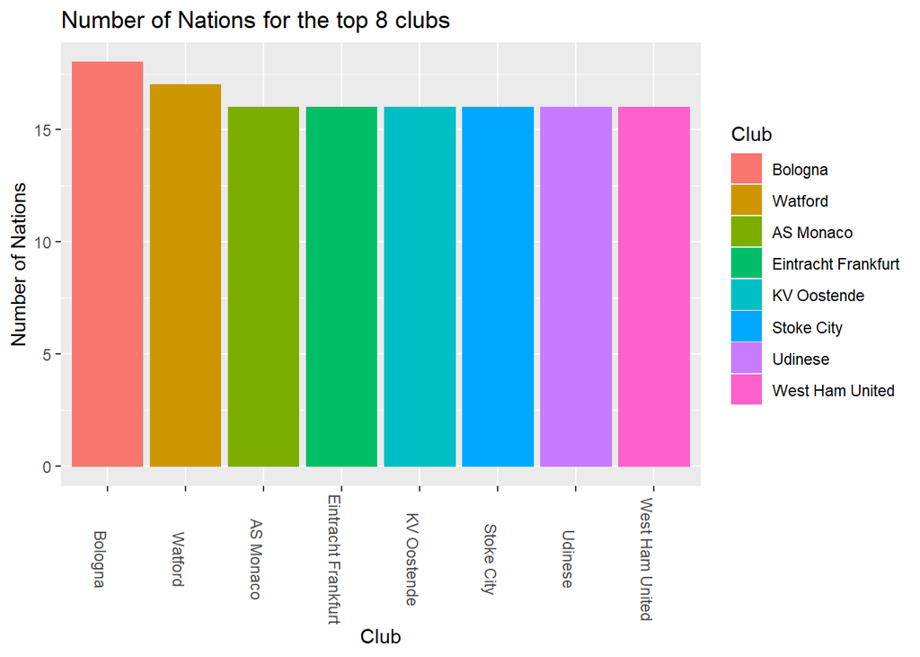

```r
#barplot for the 8 clubs with the greatest number of distinct nationalities in the club
# by counting
g <- ggplot(data = number_of_nationality_in_club %>% head(8),aes(x = Club,y = N_nation,color = Club, fill = Club))
g + geom_bar(stat="identity") +
theme(axis.text.x = element_text(angle = -90)) +
        ylab("Number of Nations") +
labs(title="Number of Nations for the top 8 clubs")
```

a fixed code - part 3:

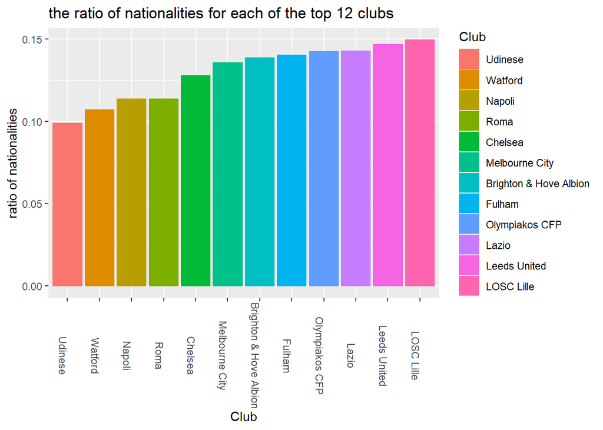

```r
#the 12 clubs with the greatest number of distinct nationalities in the club
# by using ratio
g <- ggplot(data = DIV_in_club %>% head(12),aes(x = Club, y = DIV, color = Club, fill = Club))

g + geom_bar(stat="identity") + theme(axis.text.x = element_text(angle = -90)) + ylab("ratio of nationalities") +
labs(title="the ratio of nationalities for each of the top 12 clubs")
```